# Setting Up XLconnect Package on Windows

Alok sharma

23/04/2020

## XLconnect R Package

**XLConnect** is a package that allows for **reading, writing and manipulating Microsoft Excel files** from within R.

#### Check my System Info

```r
Sys.info()
```

```
##           sysname           release           version          nodename
##         "Windows"          "10 x64"     "build 18362" "DESKTOP-59OHM3L"
##           machine             login              user    effective_user
##          "x86-64"           "neelo"           "neelo"           "neelo"
```

Install the package in R studio

```r
install.packages("XLconnect")
library(XLconnect)
```

Initially I had Java version 13, which is not compatible so i a was getting this error (Figure 1)

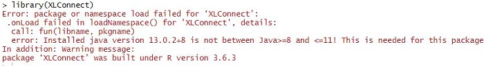

Error: Wrong Java Version Installed

```r
knitr::include_graphics("error.JPG")
```

#### Check your R Version

**R version**

```r
version
```

```
##                _
## platform       x86_64-w64-mingw32
## arch           x86_64
## os             mingw32
## system         x86_64, mingw32
## status
## major          3
## minor          6.3
## year           2020
## month          02
## day            29
## svn rev        77875
## language       R
## version.string R version 3.6.3 (2020-02-29)
## nickname       Holding the Windsock
```

- “mingw-w32” or “mingw-w64”
  - “mingw-w64” generate 64bit binaries that will run on windows natively (64bit windows required)
  - “mingw-w32” generate 32bit binaries that will run on windows natively

You can upgrade your R from Rstudio, if required

```r
install.packages("installr")
library(installr)
updateR()
```

#### Check Your Java Version

A 64-bit program will see the information on 64-bit Java, and a 32-bit program will see information on 32-bit Java.

So make sure that you have Java SDK installed is of the same 64 or 32 bit as you R-program.

ON windows command line enter command java -version and it will tell you what you got for Java

[figure not shown]

```r
knitr::include_graphics("error.JPG")
```

If you require to install JAVA, [Go Here!](https://www.oracle.com/java/technologies/javase-jdk8-downloads.html)

#### JAVA_HOME env Variable is set right

After java is installed, make sure that the environment variable **JAVA_HOME** is set right Check by entering following command

```r
Sys.getenv("JAVA_HOME")
```

```
## [1] "C:\\Program Files\\Java\\jdk1.8.0_251"
```

Make sure the variable value is set right by browsing to it  
and if its value is not set Set it by entering following command

```r
Sys.setenv(JAVA_HOME = "C:\\Program Files\\Java\\jdkx.x.x_xxx")
```

You are good to go If + R and Java are both 32 bit or 64 bit + Java version is between 8 and 11 + JAVA_HOME Environment Variable is set right